# Project 2 - Investigation of the Titanic's passenger dataset

```python
%matplotlib inline
import warnings
warnings.filterwarnings("ignore")

import numpy as np
import pandas as pd
import matplotlib as mpl
import matplotlib.pyplot as plt
import matplotlib.mlab as mlab
import seaborn as sns
from __future__ import division
from copy import copy
```

```python
titanic = pd.read_csv('titanic-data.csv')
```

### Data description

For this project I analyzed the dataset of the Titanic's passengers to uncover correlations between some of their characteristics and factors that made them more likely to survive. The dataset of the Titanic's passengers contains 12 different types of data for each of them. Below each of the data types is presented in the order it appears in the csv file:

1. 'PassengerId' - Passenger ID (1 to 891)
2. 'Survived' - Survived or not (1 and 0 respectively)
3. 'Pclass' - Passenger class $(1^{st}, 2^{nd}$ or $3^{rd})$
4. 'Name' - Passenger name (If female the name is in parenthesis after the husband's name)
5. 'Sex' - Passenger sex
6. 'Age' - Passenger age
7. 'SibSp' - Siblings or Spouses
8. 'Parch' - Parents or Children
9. 'Ticket' - Ticket number
10. 'Fare' - Ticket fare
11. 'Cabin' - Cabin number
12. 'Embarked' - Port of embarkement (Cherbourg (C), Queenstown (Q) or Southampton (S))

```python
titanic
```

|  | PassengerId | Survived | Pclass | Name | Sex | Age | SibSp | Parch | Ticket | Fare | Cabin | Embarked |
| --- | --- | --- | --- | --- | --- | --- | --- | --- | --- | --- | --- | --- |
| 0 | 1 | 0 | 3 | Braund, Mr. Owen Harris | male | 22 | 1 | 0 | A/5 21171 | 7.2500 | NaN | S |
| 1 | 2 | 1 | 1 | Cumings, Mrs. John Bradley (Florence Briggs Th... | female | 38 | 1 | 0 | PC 17599 | 71.2833 | C85 | C |
| 2 | 3 | 1 | 3 | Heikkinen, Miss. Laina | female | 26 | 0 | 0 | STON/O2. 3101282 | 7.9250 | NaN | S |
| 3 | 4 | 1 | 1 | Futrelle, Mrs. Jacques Heath (Lily May Peel) | female | 35 | 1 | 0 | 113803 | 53.1000 | C123 | S |
| 4 | 5 | 0 | 3 | Allen, Mr. William Henry | male | 35 | 0 | 0 | 373450 | 8.0500 | NaN | S |
| 5 | 6 | 0 | 3 | Moran, Mr. James | male | NaN | 0 | 0 | 330877 | 8.4583 | NaN | Q |
| 6 | 7 | 0 | 1 | McCarthy, Mr. Timothy J | male | 54 | 0 | 0 | 17463 | 51.8625 | E46 | S |
| 7 | 8 | 0 | 3 | Palsson, Master. Gosta Leonard | male | 2 | 3 | 1 | 349909 | 21.0750 | NaN | S |
| 8 | 9 | 1 | 3 | Johnson, Mrs. Oscar W (Elisabeth Vilhelmina Berg) | female | 27 | 0 | 2 | 347742 | 11.1333 | NaN | S |
| 9 | 10 | 1 | 2 | Nasser, Mrs. Nicholas (Adele Achem) | female | 14 | 1 | 0 | 237736 | 30.0708 | NaN | C |
| 10 | 11 | 1 | 3 | Sandstrom, Miss. Marguerite Rut | female | 4 | 1 | 1 | PP 9549 | 16.7000 | G6 | S |
| 11 | 12 | 1 | 1 | Bonnell, Miss. Elizabeth | female | 58 | 0 | 0 | 113783 | 26.5500 | C103 | S |
| 12 | 13 | 0 | 3 | Saundercock, Mr. William Henry | male | 20 | 0 | 0 | A/5. 2151 | 8.0500 | NaN | S |
| 13 | 14 | 0 | 3 | Andersson, Mr. Anders Johan | male | 39 | 1 | 5 | 347082 | 31.2750 | NaN | S |
| 14 | 15 | 0 | 3 | Vestrom, Miss. Hulda Amanda Adolfina | female | 14 | 0 | 0 | 350406 | 7.8542 | NaN | S |
| 15 | 16 | 1 | 2 | Hewlett, Mrs. (Mary D Kingcome) | female | 55 | 0 | 0 | 248706 | 16.0000 | NaN | S |
| 16 | 17 | 0 | 3 | Rice, Master. Eugene | male | 2 | 4 | 1 | 382652 | 29.1250 | NaN | Q |
| 17 | 18 | 1 | 2 | Williams, Mr. Charles Eugene | male | NaN | 0 | 0 | 244373 | 13.0000 | NaN | S |
| 18 | 19 | 0 | 3 | Vander Planke, Mrs. Julius (Emelia Maria Vande... | female | 31 | 1 | 0 | 345763 | 18.0000 | NaN | S |
| 19 | 20 | 1 | 3 | Masselmani, Mrs. Fatima | female | NaN | 0 | 0 | 2649 | 7.2250 | NaN | C |
| 20 | 21 | 0 | 2 | Fynney, Mr. Joseph J | male | 35 | 0 | 0 | 239865 | 26.0000 | NaN | S |
| 21 | 22 | 1 | 2 | Beesley, Mr. Lawrence | male | 34 | 0 | 0 | 248698 | 13.0000 | D56 | S |
| 22 | 23 | 1 | 3 | McGowan, Miss. Anna "Annie" | female | 15 | 0 | 0 | 330923 | 8.0292 | NaN | Q |
| 23 | 24 | 1 | 1 | Sloper, Mr. William Thompson | male | 28 | 0 | 0 | 113788 | 35.5000 | A6 | S |
| 24 | 25 | 0 | 3 | Palsson, Miss. Torborg Danira | female | 8 | 3 | 1 | 349909 | 21.0750 | NaN | S |
| 25 | 26 | 1 | 3 | Asplund, Mrs. Carl Oscar (Selma Augusta Emilia... | female | 38 | 1 | 5 | 347077 | 31.3875 | NaN | S |
| 26 | 27 | 0 | 3 | Emir, Mr. Farred Chehab | male | NaN | 0 | 0 | 2631 | 7.2250 | NaN | C |
| 27 | 28 | 0 | 1 | Fortune, Mr. Charles Alexander | male | 19 | 3 | 2 | 19950 | 263.0000 | C23 C25 C27 | S |
| 28 | 29 | 1 | 3 | O'Dwyer, Miss. Ellen "Nellie" | female | NaN | 0 | 0 | 330959 | 7.8792 | NaN | Q |
| 29 | 30 | 0 | 3 | Todoroff, Mr. Lalio | male | NaN | 0 | 0 | 349216 | 7.8958 | NaN | S |
| ... | ... | ... | ... | ... | ... | ... | ... | ... | ... | ... | ... | ... |
| 861 | 862 | 0 | 2 | Giles, Mr. Frederick Edward | male | 21 | 1 | 0 | 28134 | 11.5000 | NaN | S |
| 862 | 863 | 1 | 1 | Swift, Mrs. Frederick Joel (Margaret Welles Ba... | female | 48 | 0 | 0 | 17466 | 25.9292 | D17 | S |
| 863 | 864 | 0 | 3 | Sage, Miss. Dorothy Edith "Dolly" | female | NaN | 8 | 2 | CA. 2343 | 69.5500 | NaN | S |
| 864 | 865 | 0 | 2 | Gill, Mr. John William | male | 24 | 0 | 0 | 233866 | 13.0000 | NaN | S |
| 865 | 866 | 1 | 2 | Bystrom, Mrs. (Karolina) | female | 42 | 0 | 0 | 236852 | 13.0000 | NaN | S |
| 866 | 867 | 1 | 2 | Duran y More, Miss. Asuncion | female | 27 | 1 | 0 | SC/PARIS 2149 | 13.8583 | NaN | C |
| 867 | 868 | 0 | 1 | Roebling, Mr. Washington Augustus II | male | 31 | 0 | 0 | PC 17590 | 50.4958 | A24 | S |
| 868 | 869 | 0 | 3 | van Melkebeke, Mr. Philemon | male | NaN | 0 | 0 | 345777 | 9.5000 | NaN | S |
| 869 | 870 | 1 | 3 | Johnson, Master. Harold Theodor | male | 4 | 1 | 1 | 347742 | 11.1333 | NaN | S |
| 870 | 871 | 0 | 3 | Balkic, Mr. Cerin | male | 26 | 0 | 0 | 349248 | 7.8958 | NaN | S |
| 871 | 872 | 1 | 1 | Beckwith, Mrs. Richard Leonard (Sallie Monypeny) | female | 47 | 1 | 1 | 11751 | 52.5542 | D35 | S |
| 872 | 873 | 0 | 1 | Carlsson, Mr. Frans Olof | male | 33 | 0 | 0 | 695 | 5.0000 | B51 B53 B55 | S |
| 873 | 874 | 0 | 3 | Vander Cruyssen, Mr. Victor | male | 47 | 0 | 0 | 345765 | 9.0000 | NaN | S |
| 874 | 875 | 1 | 2 | Abelson, Mrs. Samuel (Hannah Wizosky) | female | 28 | 1 | 0 | P/PP 3381 | 24.0000 | NaN | C |
| 875 | 876 | 1 | 3 | Najib, Miss. Adele Kiamie "Jane" | female | 15 | 0 | 0 | 2667 | 7.2250 | NaN | C |
| 876 | 877 | 0 | 3 | Gustafsson, Mr. Alfred Ossian | male | 20 | 0 | 0 | 7534 | 9.8458 | NaN | S |
| 877 | 878 | 0 | 3 | Petroff, Mr. Nedelio | male | 19 | 0 | 0 | 349212 | 7.8958 | NaN | S |
| 878 | 879 | 0 | 3 | Laleff, Mr. Kristo | male | NaN | 0 | 0 | 349217 | 7.8958 | NaN | S |
| 879 | 880 | 1 | 1 | Potter, Mrs. Thomas Jr (Lily Alexenia Wilson) | female | 56 | 0 | 1 | 11767 | 83.1583 | C50 | C |
| 880 | 881 | 1 | 2 | Shelley, Mrs. William (Imanita Parrish Hall) | female | 25 | 0 | 1 | 230433 | 26.0000 | NaN | S |
| 881 | 882 | 0 | 3 | Markun, Mr. Johann | male | 33 | 0 | 0 | 349257 | 7.8958 | NaN | S |
| 882 | 883 | 0 | 3 | Dahlberg, Miss. Gerda Ulrika | female | 22 | 0 | 0 | 7552 | 10.5167 | NaN | S |
| 883 | 884 | 0 | 2 | Banfield, Mr. Frederick James | male | 28 | 0 | 0 | C.A./SOTON 34068 | 10.5000 | NaN | S |
| 884 | 885 | 0 | 3 | Sutehall, Mr. Henry Jr | male | 25 | 0 | 0 | SOTON/OQ 392076 | 7.0500 | NaN | S |
| 885 | 886 | 0 | 3 | Rice, Mrs. William (Margaret Norton) | female | 39 | 0 | 5 | 382652 | 29.1250 | NaN | Q |
| 886 | 887 | 0 | 2 | Montvila, Rev. Juozas | male | 27 | 0 | 0 | 211536 | 13.0000 | NaN | S |
| 887 | 888 | 1 | 1 | Graham, Miss. Margaret Edith | female | 19 | 0 | 0 | 112053 | 30.0000 | B42 | S |
| 888 | 889 | 0 | 3 | Johnston, Miss. Catherine Helen "Carrie" | female | NaN | 1 | 2 | W./C. 6607 | 23.4500 | NaN | S |
| 889 | 890 | 1 | 1 | Behr, Mr. Karl Howell | male | 26 | 0 | 0 | 111369 | 30.0000 | C148 | C |
| 890 | 891 | 0 | 3 | Dooley, Mr. Patrick | male | 32 | 0 | 0 | 370376 | 7.7500 | NaN | Q |

891 rows × 12 columns

### Methods

I analyzed whether the following characteristics affected the passengers' survival rates:

```
1. The passengers' sex
2. The passengers' age characteristics
3. Whether the passenger was a child. If yes, was it accompanied by his/her parent(s) or not
4. How the likelihood to die was affected by the class of the ticket for males and females
```

Due to evacuation priorities men and women are expected to have different likelihood of survival. Thus I split the data and the analysis between men and women for all questions apart from the third. As children I selected all those of less than 16 years old. I made this choice because of one passenger who was 16 years old with Pchild value equal to 3. This passenger was obviously both parent and child and thus I excluded him/her from that part of the analysis.

##### Cleaning the data

In our data there are various missing points, for example in the 'Age' and 'Cabin' columns there are 177 and 687 NaN values respectively. I didn't analyse any data requiring the 'Cabin' column due to the fact that about 77% of the data are missing. However, about 80% of the passengers ages are present, which made possible to analyze it. Since no assumptions could be made in order to impute the missing data, I ignored them and worked with the 80% of the dataset for that analysis. I used the pandas method 'dropna()' to ignore the NaN, when necessary.

```python
print sum(pd.isnull(titanic['Age'])), sum(pd.isnull(titanic['Cabin']))
```

```
177 687
```

### Results

##### 1. The passenger's sex

```python
# Splitting of data by the passenger's sex
women = copy(titanic[titanic['Sex'] == 'female'])
men = copy(titanic[titanic['Sex'] == 'male'])

women_total = len(women)
men_total = len(men)

women_survived_total = women.groupby('Survived').size()[1]
women_died_total = women_total - women_survived_total

men_survived_total = men.groupby('Survived').size()[1]
men_died_total = men_total - men_survived_total
```

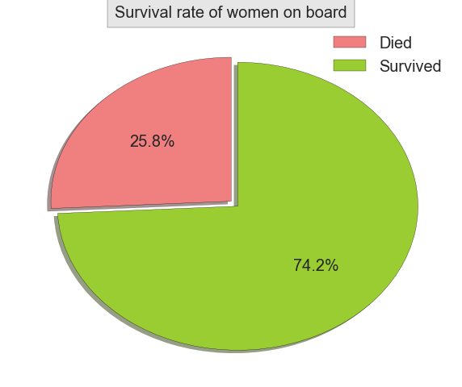

```python
plt.figure(figsize=(10, 8));

labels = ['Died', 'Survived']
colors = ['lightcoral', 'yellowgreen']
fracs = [women_died_total/women_total, women_survived_total/women_total]
explode = (0, 0.05)

mpl.rcParams['font.size'] = 20

plt.pie(fracs, colors = colors,
               explode = explode,
               autopct='%1.1f%%',
               shadow=True,
               startangle=90)

plt.title('Survival rate of women on board', bbox={'facecolor':'0.9', 'pad':9}, fontsize = 20)
plt.legend(labels, loc="best", fontsize = 20)

plt.show()
```

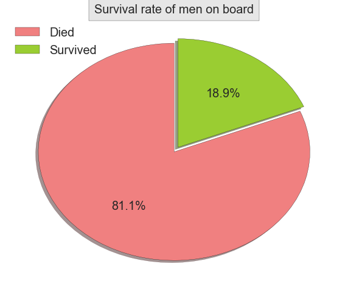

```python
plt.figure(figsize=(10, 8));

labels = ['Died', 'Survived']
colors = ['lightcoral', 'yellowgreen']
fracs = [men_died_total/men_total, men_survived_total/men_total]
explode = (0, 0.05)

mpl.rcParams['font.size'] = 20

plt.pie(fracs, colors = colors,
               explode = explode,
               autopct='%1.1f%%',
               shadow=True,
               startangle=90)

plt.title('Survival rate of men on board', bbox={'facecolor':'0.9', 'pad':9}, fontsize = 20)
plt.legend(labels, loc="best", fontsize = 20)

plt.show()
```

##### Discussion

From the previous two pie charts we can clearly see that the vast majority of women (74.2%) survived the accident while the vast majority of men (81.1%) didn't. This was a direct consequence of the evacuation procedure which prioritized women and children.

##### 2. The passengers' age characteristics

```python
women_survived = women.groupby('Survived')
men_survived = men.groupby('Survived')

# Mean age of all passengers on board
[mean_age_total, std_age_total] = [titanic.mean()['Age'], titanic.std()['Age']]

# Mean age of all men and women on board
[mean_age_women, mean_age_men] = [women.mean()['Age'], men.mean()['Age']]
[std_age_women, std_age_men] = [women.std()['Age'], men.std()['Age']]

# Mean age of all men and women who died
[mean_age_women_died, mean_age_men_died] = [women_survived.mean()['Age'][0], men_survived.mean()['Age'][0]]
[std_age_women_died, std_age_men_died] = [women_survived.std()['Age'][0], men_survived.std()['Age'][0]]

# Mean age of all mean and women who survived
[mean_age_women_survived, mean_age_men_survived] = [women_survived.mean()['Age'][1], men_survived.mean()['Age'][1]]
[std_age_women_survived, std_age_men_survived] = [women_survived.std()['Age'][1], men_survived.std()['Age'][1]]

# Putting everything in a dataframe for nicer presentation
mean_ages = pd.DataFrame({'Survived': ['%.0f' % mean_age_women_survived + ' ± %.0f years old' % std_age_women_survived, \
                                       '%.0f' % mean_age_men_survived + ' ± %.0f years old' % std_age_men_survived],
                         'Died':['%.0f' % mean_age_women_died + ' ± %.0f years old' % std_age_women_died, \
                                       '%.0f' % mean_age_men_died + ' ± %.0f years old' % std_age_men_died], \
                         'Total':['%.0f' % mean_age_women + ' ± %.0f years old' % std_age_women, \
                                       '%.0f' % mean_age_men + ' ± %.0f years old' % std_age_men]},
                        index = ['Women', 'Men'])

mean_ages.columns.names  = ['Average age']
mean_ages
```

| Average age | Died | Survived | Total |
| --- | --- | --- | --- |
| Women | 25 ± 14 years old | 29 ± 14 years old | 28 ± 14 years old |
| Men | 32 ± 14 years old | 27 ± 17 years old | 31 ± 15 years old |

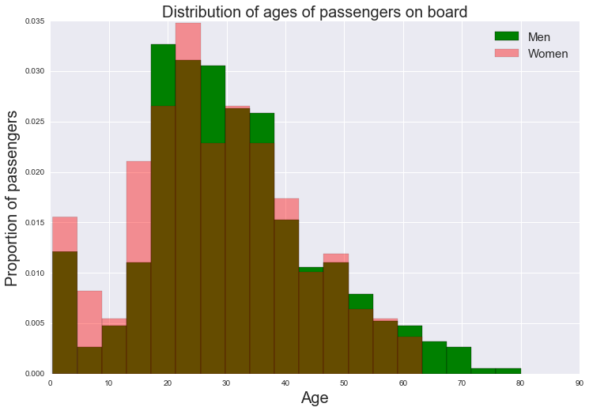

```python
# This is the histogram of the ages of men and women on board. I used the pandas
# method dropna() to ignore missing data.
women_ages_nonan = women['Age'].dropna()
men_ages_nonan = men['Age'].dropna()

plt.figure(figsize=(12, 8));

bins = np.linspace(min(titanic['Age']), max(titanic['Age']), 20)

# the histogram of the data
plt.hist(men_ages_nonan, \
        normed=1, \
        bins = bins, \
        facecolor='g', \
        alpha=1,\
        label = 'Men')

plt.hist(women_ages_nonan, \
        normed=1, \
        bins = bins, \
        facecolor='r', \
        alpha= 0.4,\
        label = 'Women')




plt.xlabel('Age', fontsize = 20)
plt.ylabel('Proportion of passengers', fontsize = 20)
plt.title('Distribution of ages of passengers on board', fontsize = 20)
plt.legend(loc='best', fontsize=15)

plt.show()
```

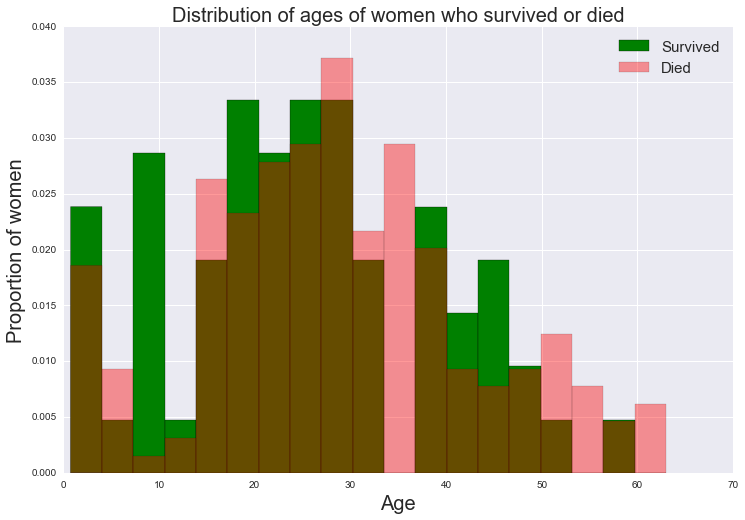

```python
plt.figure(figsize=(12, 8));

bins = np.linspace(min(women['Age']), max(women['Age']), 20)
women_survived_data = women[women['Survived'] == 0]
women_died_data = women[women['Survived'] == 1]

# the histogram of the data
plt.hist(women_survived_data['Age'].dropna(), \
        normed=1, \
        bins = bins, \
        facecolor='g', \
        alpha=1,\
        label = 'Survived')

plt.hist(women_died_data['Age'].dropna(), \
        normed=1, \
        bins = bins, \
        facecolor='r', \
        alpha= 0.4,\
        label = 'Died')




plt.xlabel('Age', fontsize = 20)
plt.ylabel('Proportion of women', fontsize = 20)
plt.title('Distribution of ages of women who survived or died', fontsize = 20)
plt.legend(loc='best', fontsize=15)

plt.show()
```

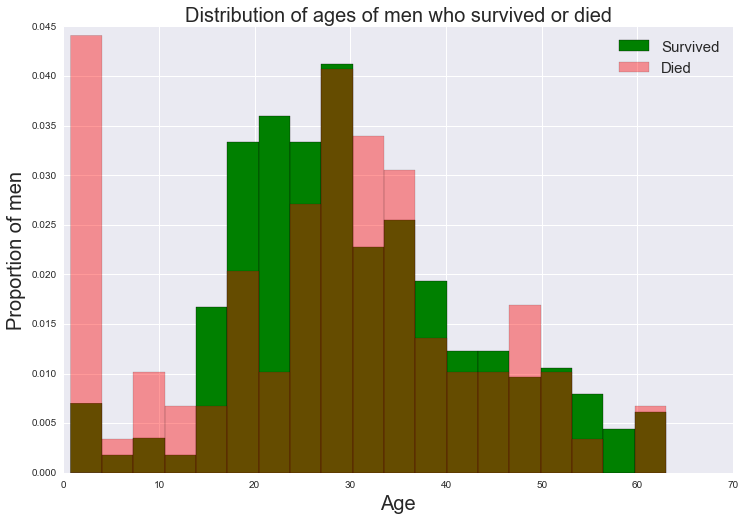

```python
plt.figure(figsize=(12, 8));

bins = np.linspace(min(women['Age']), max(women['Age']), 20)
men_survived_data = men[men['Survived'] == 0]
men_died_data = men[men['Survived'] == 1]

# the histogram of the data
plt.hist(men_survived_data['Age'].dropna(), \
        normed=1, \
        bins = bins, \
        facecolor='g', \
        alpha=1,\
        label = 'Survived')

plt.hist(men_died_data['Age'].dropna(), \
        normed=1, \
        bins = bins, \
        facecolor='r', \
        alpha= 0.4,\
        label = 'Died')




plt.xlabel('Age', fontsize = 20)
plt.ylabel('Proportion of men', fontsize = 20)
plt.title('Distribution of ages of men who survived or died', fontsize = 20)
plt.legend(loc='best', fontsize=15)

plt.show()
```

##### Discussion

From the distributions of the ages of the passengers we can see that the majority of passengers were between 17 and 40 years old along with a lot of very young kids.

##### 3. Whether the passenger was a child. If yes, was it accompanied by his/her parent or not

```python
# Isolating the childrens' data from the whole dataset
children = copy(titanic[titanic['Age'] < 16])
children_per_companion = children.groupby('Parch').size()
```

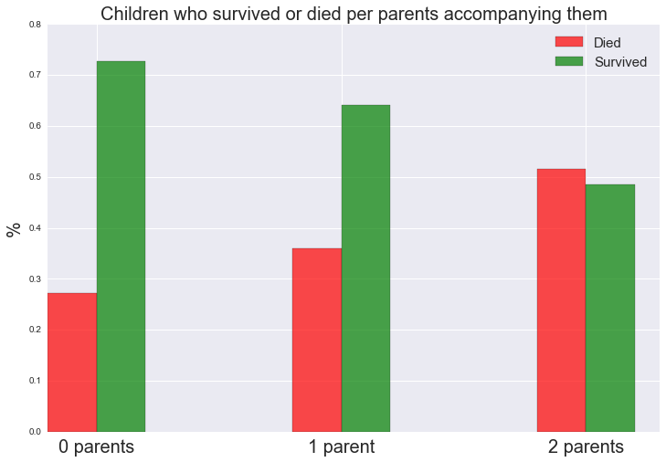

```python
plt.figure(figsize=(12, 8));

index = np.arange(3)
bar_width = 0.2


children_died_companion_bar = plt.bar(index, \
                               children.groupby(['Survived','Parch']).size()[0]/children_per_companion, \
                               bar_width, \
                               color='r', \
                               alpha = 0.7,\
                               label = 'Died')

children_survived_companion_bar = plt.bar(index + bar_width, \
                                   children.groupby(['Survived','Parch']).size()[1]/children_per_companion, \
                                   bar_width, \
                                   color = 'g', \
                                   alpha = 0.7,\
                                   label = 'Survived')

plt.ylabel('%', fontsize=20)
plt.title('Children who survived or died per parents accompanying them', fontsize=20)
plt.xticks(index + bar_width, ('0 parents', '1 parent', '2 parents'), fontsize = 20)

plt.legend(loc='best', fontsize=15)
plt.show()
```

##### Discussion

From the previous bar plot we can see that unacompanied children were more than twice more likely to survive than die, while being accompanied by parents made them less and less likely to survive. This is a counterintuitive result because one would expect that parents would help children evacuate. However, it seems that being without a parent on the boat somehow helped children to escape it more easily than the rest of them.

##### 4. How the likelihood to die is affected by the class of the ticket for males and females

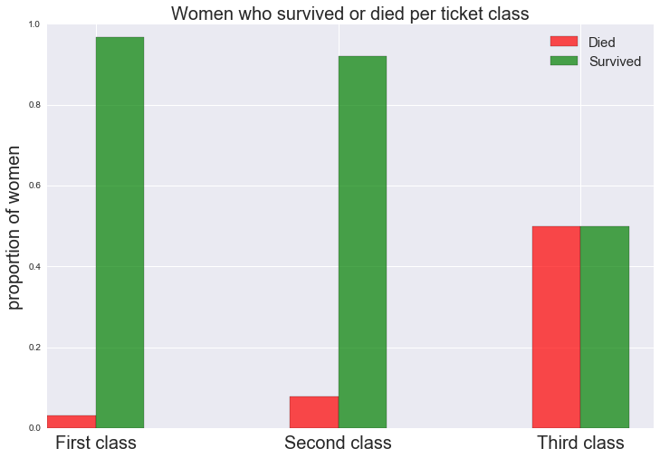

```python
plt.figure(figsize=(12, 8));

index = np.arange(3)
bar_width = 0.2

women_by_class = titanic.groupby(['Pclass','Sex']).size()[0:5:2]


women_died_class_bar = plt.bar(index, \
                               titanic.groupby(['Survived','Pclass','Sex']).size()[0][0:5:2]/women_by_class, \
                               bar_width, \
                               color='r', \
                               alpha = 0.7, \
                               label = 'Died')

women_survived_class_bar = plt.bar(index + bar_width, \
                                   titanic.groupby(['Survived','Pclass','Sex']).size()[1][0:5:2]/women_by_class, \
                                   bar_width, \
                                   color = 'g', \
                                   alpha = 0.7,\
                                   label = 'Survived')

plt.ylabel('proportion of women', fontsize=20)
plt.title('Women who survived or died per ticket class', fontsize=20)
plt.xticks(index + bar_width, ('First class', 'Second class', 'Third class'), fontsize = 20)

plt.legend(loc='best', fontsize=15)
plt.show()
```

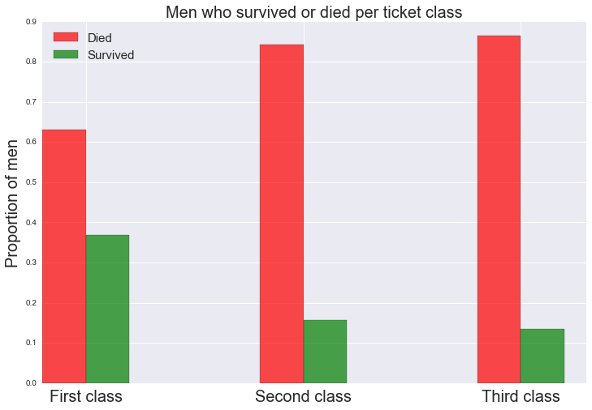

```python
plt.figure(figsize=(12, 8));

index = np.arange(3)
bar_width = 0.2

men_by_class = titanic.groupby(['Pclass','Sex']).size()[1:6:2]

men_died_class_bar = plt.bar(index, \
                               titanic.groupby(['Survived','Pclass','Sex']).size()[0][1:6:2]/men_by_class, \
                               bar_width, \
                               color='r', \
                               alpha = 0.7,\
                               label = 'Died')

men_survived_class_bar = plt.bar(index + bar_width, \
                                   titanic.groupby(['Survived','Pclass','Sex']).size()[1][1:6:2]/men_by_class, \
                                   bar_width, \
                                   color = 'g', \
                                   alpha = 0.7,\
                                   label = 'Survived')

plt.ylabel('Proportion of men', fontsize=20)
plt.title('Men who survived or died per ticket class', fontsize=20)
plt.xticks(index + bar_width, ('First class', 'Second class', 'Third class'), fontsize = 20)

plt.legend(loc='best', fontsize=15)
plt.show()
```

### Conclusion

To sum up, the majority of losses in the Titanic came from the male population on board and especially from those of middle to lower class. Men coming from the higher class had clearly more chances to survive than the rest. Almost all women of middle to higher class survived the sink, while those of lower class had equal chances to survive or die. Among children, those that were without any parents were more than twice more likely to survive than die, where the rest had less chances with growing number of parents along them. Finally, it is imprortant to notice that this dataset contains data for 891 out of the about 2,200 passengers of the Titanic. Thus any results from analyzing them, without further knowledge on whether these data are representative of the population or not, should be taken with a grain of salt.

## References

Data explanation: https://www.kaggle.com/c/titanic/data

About Titanic: https://en.wikipedia.org/wiki/RMS_Titanic

Pandas documentation: http://pandas.pydata.org/pandas-docs/stable/

Python 3 division: http://stackoverflow.com/questions/1267869/how-can-i-force-division-to-be-floating-point-in-python-division-keeps-rounding

Seaborn documentation: http://seaborn.pydata.org

Matplotlib documentation: http://matplotlib.org/1.2.1/index.html

Change figure size: http://stackoverflow.com/questions/332289/how-do-you-change-the-size-of-figures-drawn-with-matplotlib

Reason for ignoring the warning for the color_cycle at the importing stage: https://github.com/mwaskom/seaborn/pull/739

Label size in pie charts: http://stackoverflow.com/questions/7082345/how-to-set-the-labels-size-on-a-pie-chart-in-python